# Formula 1 Champions Point Total Per Season

Coursework 1 – 230093746

Mudassar Motlekar

Spring Term 2025

# Introduction

##### This project will analyse the championship points total for F1 drivers per season, dating from 1950-2025.

# Data

##### Formula 1 began in 1950 and we have 76 years of data.

```r
df = data.frame(
    ds = 1950:2025,
    y = c(30, 31, 36, 34.5, 42, 40, 30, 40, 42, 31, 43, 34, 42, 54, 40, 54, 42,
          51, 48, 63, 45, 62, 61, 71, 55, 64.5, 69, 72, 64, 51, 67, 50,
          44, 59, 72, 73, 72, 73, 90, 76, 78, 96, 108, 99, 92, 102, 97, 81,
          100, 76, 108, 123, 133, 93, 148, 133, 134, 110, 98, 95, 256, 392,
          281, 397, 384, 381, 385, 363, 408, 413, 347, 395.5, 454, 575, 437, 423)
)
```

# Time Series Plot of F1 Seasons

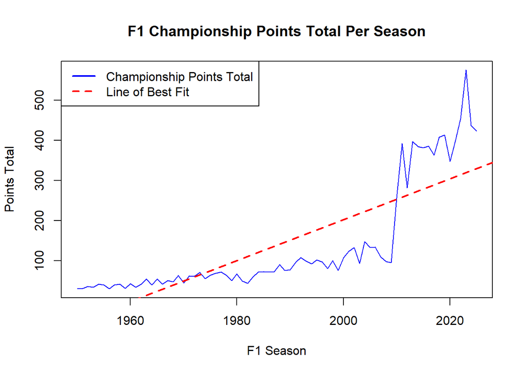

```r
f1_ts = ts(df$y, start = 1950, frequency = 1)
plot(f1_ts, main = "F1 Championship Points Total Per Season",
     ylab = "Points Total",
     xlab = "F1 Season",
     col = "blue",
     )
abline(reg = lm(f1_ts ~ time(f1_ts)), col = "red", lwd = 2, lty = 2)
legend("topleft", legend = c("Championship Points Total", "Line of Best Fit"),
       col = c("blue", "red"), lty = c(1, 2), lwd = 2)
```

## Time Series Adjusting for Point System Change

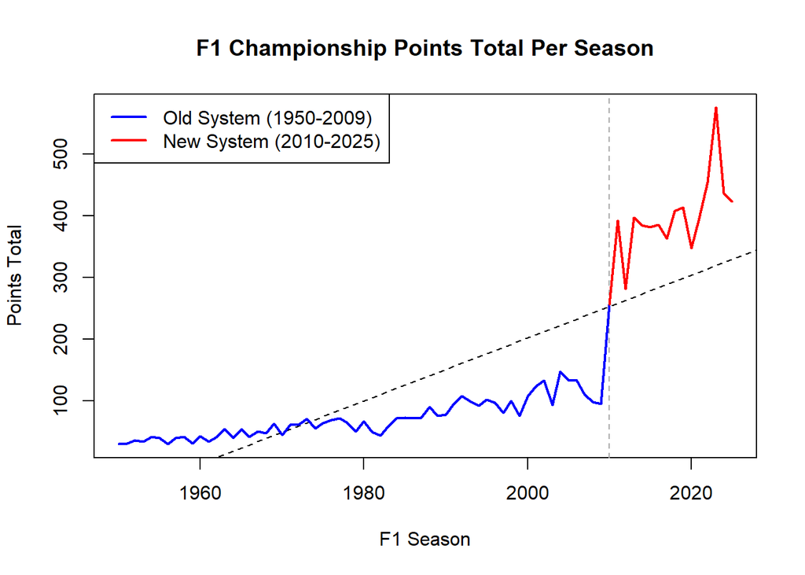

```r
old_system = subset(df, ds <= 2010)
new_system = subset(df, ds >= 2010)
plot(df$ds, df$y, type = "n",
     main = "F1 Championship Points Total Per Season",
     ylab = "Points Total",
     xlab = "F1 Season")
abline(v = 2010, lty = 2, col = "darkgrey")
abline(lm(y ~ ds, data = df), col = "black", lwd = 1, lty = 2)
lines(old_system$ds, old_system$y, col = "blue", lwd = 2)
lines(new_system$ds, new_system$y, col = "red", lwd = 2)
legend("topleft",
       legend = c("Old System (1950-2009)", "New System (2010-2025)"),
       col = c("blue", "red"),
       lty = 1,
       lwd = 2)
```

##### In 2010, the points system changed to the current one which explains the steep jump in points total in from 2009-2010.

##### We can highlight this on the time series and include a legend to help us distinguish between the 2 points systems.

## Old System vs New System

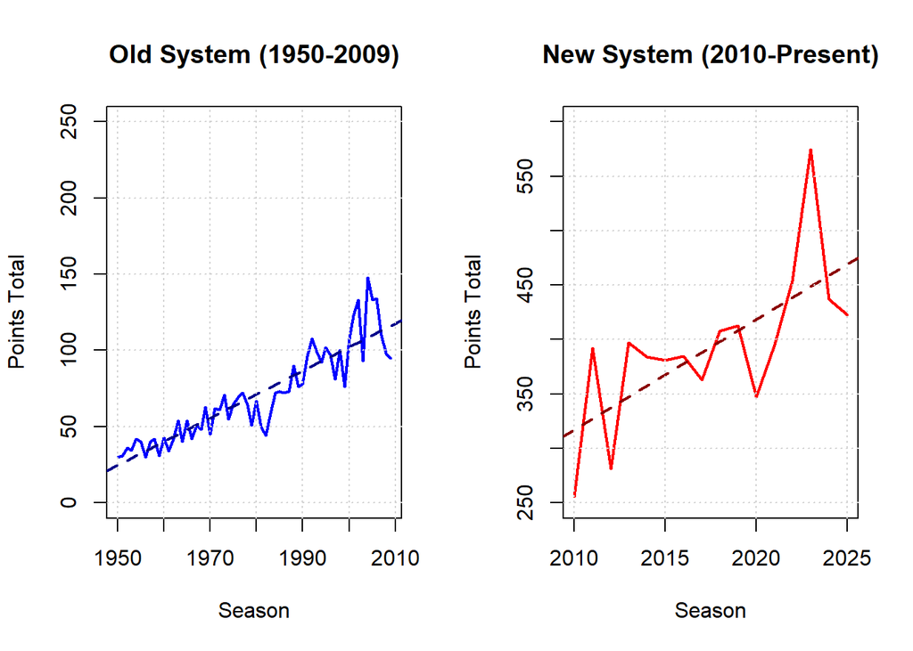

```r
par(mfrow = c(1, 2))
old_system <- subset(df, ds <= 2009)
fit_old <- lm(y ~ ds, data = old_system)
plot(old_system$ds, old_system$y, type = "l", col = "blue", lwd = 2,
     main = "Old System (1950-2009)",
     xlab = "Season", ylab = "Points Total",
     ylim = c(0, 250))
abline(fit_old, col = "darkblue", lty = 2, lwd = 2)
grid()
new_system <- subset(df, ds >= 2010)
fit_new <- lm(y ~ ds, data = new_system)
plot(new_system$ds, new_system$y, type = "l", col = "red", lwd = 2,
     main = "New System (2010-Present)",
     xlab = "Season", ylab = "Points Total",
     ylim = c(250, 600))
abline(fit_new, col = "darkred", lty = 2, lwd = 2)
grid()
```

```r
par(mfrow = c(1, 1))
```

##### On the separate graphs, we are able to see much more noticeable differences in championship points totals prior to the points system change whereas on the combined graph, the steep climbs overwhelm due to their scale.

##### The graph separation also shows us that the speed of points inflation has accelerated as well since not only are there more points to be won in a race, there are also more points to be won overall due to the addition of more Grands Prix as well as sprint races.

# Forecasting using Prophet

## Forecasting Next 5 F1 Seasons Championship Total

```
## Disabling weekly seasonality. Run prophet with weekly.seasonality=TRUE to override this.
```

```
## Disabling daily seasonality. Run prophet with daily.seasonality=TRUE to override this.
```

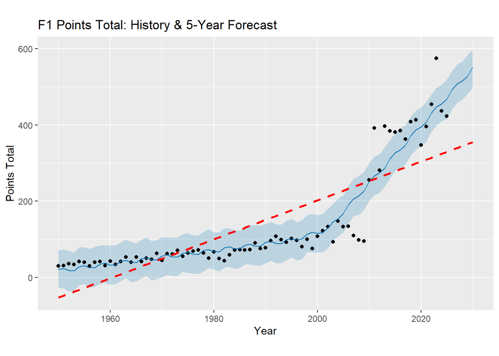

##### Here we can see the difference between a line of best fit for a linear model and Prophet’s forecasting model.

##### The linear model predicts a negative points total in the 1950s which is impossible and it also fails to account for the point system change in 2010.

##### The Prophet model acknowledges the points change which explains the slope upwards and so the 5 year forecast is much more realistic.

## Forecasting Next 5 F1 Seasons Championship Total: Old System vs New System

```
## Disabling weekly seasonality. Run prophet with weekly.seasonality=TRUE to override this.
```

```
## Disabling daily seasonality. Run prophet with daily.seasonality=TRUE to override this.
```

```
## Disabling weekly seasonality. Run prophet with weekly.seasonality=TRUE to override this.
```

```
## Disabling daily seasonality. Run prophet with daily.seasonality=TRUE to override this.
```

```
## n.changepoints greater than number of observations. Using 11
```

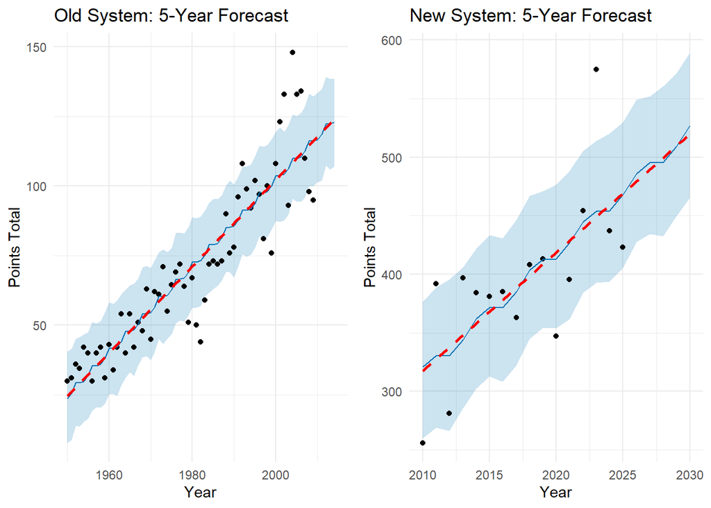

##### Now that there are 2 separate forecast graphs, we are able to see the growth of the old points system much more clearly as well as the possible points totals if F1 had continued with it whereas on the combined graph, the growths appear insignificant in comparison to the modern points system.

##### Between 1950-2009, the number of races increased from 7 to only 17 which is the main slope driver, hence why Prophet identifies this as a long-term, steady climb with minimal volatility.

##### The modern system forecast is much more prominent and the main driver is the change in point densities as there are now sprint races in certain F1 Grand Prix weekends, leading to more points available to be won.

# Log Transformations

## Log Transformations: Combined System

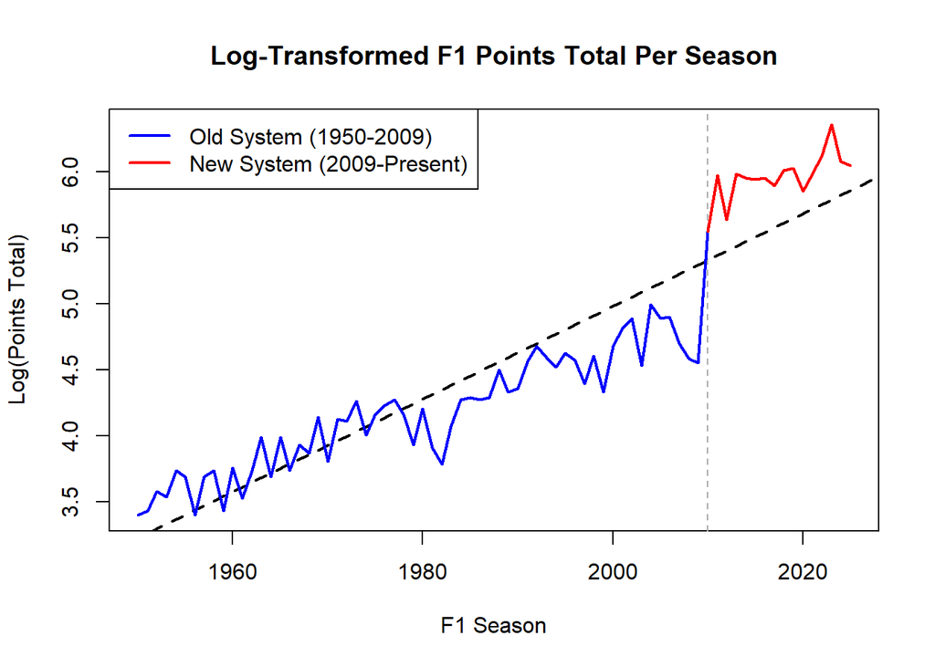

```r
old_system = subset(df, ds <= 2010)
new_system = subset(df, ds >= 2010)
plot(df$ds, log(df$y), type = "n",
     main = "Log-Transformed F1 Points Total Per Season",
     ylab = "Log(Points Total)",
     xlab = "F1 Season")
abline(v = 2010, lty = 2, col = "darkgrey")
fit = lm(log(y) ~ ds, data = df)
abline(fit, col = "black", lwd = 2, lty = 2)
lines(old_system$ds, log(old_system$y), col = "blue", lwd = 2)
lines(new_system$ds, log(new_system$y), col = "red", lwd = 2)
legend("topleft",
       legend = c("Old System (1950-2009)", "New System (2009-Present)"),
       col = c("blue", "red"), lty = 1, lwd = 2)
```

##### Furthermore, the linear graph is unable to tell us whether or not a champion had a “strong” or “weak” year between 1950-1960. However, the log graph acknowledges this since fluctuations in the 1950s are just as noticeable in the 2020s.

##### As a result, the log transformation is better for detecting relative change, for instance, a 10 point drop in 1955 was just as significant in the standings than as a 100 point drop today.

## Log Transformation: Old System vs New System

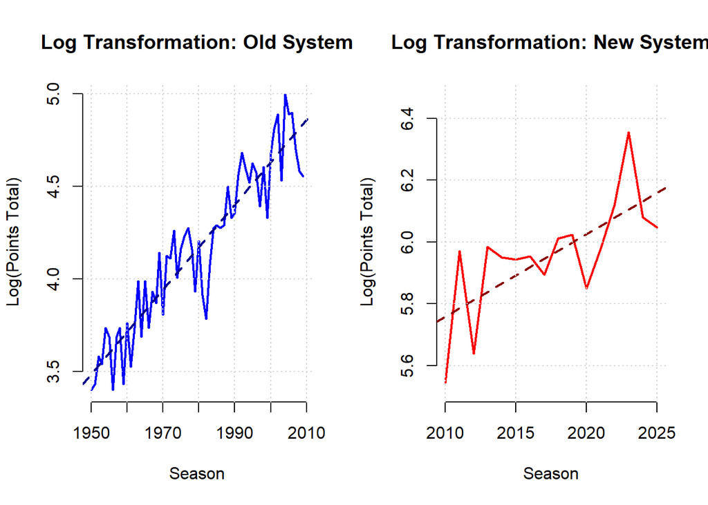

```r
par(mfrow = c(1, 2))
old_system <- subset(df, ds <= 2009)
fit_old <- lm(log(y) ~ ds, data = old_system)
plot(old_system$ds, log(old_system$y), type = "l", col = "blue", lwd = 2,
     main = "Log Transformation: Old System",
     xlab = "Season", ylab = "Log(Points Total)",
     bty = "n")
abline(fit_old, col = "darkblue", lty = 2, lwd = 2)
grid(lty = "dotted")
new_system <- subset(df, ds >= 2010)
fit_new <- lm(log(y) ~ ds, data = new_system)
plot(new_system$ds, log(new_system$y), type = "l", col = "red", lwd = 2,
     main = "Log Transformation: New System",
     xlab = "Season", ylab = "Log(Points Total)",
     ylim = c(log(250), log(650)), # Log-transformed limits
     bty = "n")
abline(fit_new, col = "darkred", lty = 2, lwd = 2)
grid(lty = "dotted")
```

```r
par(mfrow = c(1, 1))
```

# Conclusion

##### The point system change in 2010 represents the most significant change in the sports history, although it appears to be a ‘explosion’ in the linear system, the log graph displays the shift as more gentle since F1 is a sport that has constantly been growing, regardless of its scale, since the first race in 1950 in Silverstone.

##### For the next 5 years, Prophet tells us that F1 drivers are on trajectory to win between 500-600 points in a single season, assuming that the sport keeps growing and adding more races and sprint races to the calender. However, 24 races in a season is the most there have ever been and is already quite demanding for drivers and teams in terms of logistics as it necessitates transporting billions of pounds of equipment to 24+ different locations across the globe. Since the races take place on weekends, it would involve having to host races 4 weeks in a row which is extremely demanding for drivers due to the intense physical toll it takes on their body and it would not allow sufficient periods of time for recovery.

##### For a future project, it would be interesting to produce a similar time series on the F1 Constructors’ Championship which the teams compete against each other instead of the individual drivers. There are significantly much more points available in this championship as there are 2 drivers per team and the tally is the sum of the 2 drivers. I imagine there to be a much greater jump between the old point system and the modern one due to the scale of points available and the fact that the winners of the Constructors’ Championship tend to win in dominating fashion, more often than not. In 2023, for example, Mercedes finished 2nd with 409 points, in comparison, Red Bull finished with 860 out of a possible 1013, winning 84.9% of all possible points available that season.

# References

F1 points reference:

[Champions per season - Formula 1 points](https://www.formula1points.com/champions/champions-season)